# Analysis of hunting effects on spatial structure of trees with different dispersers

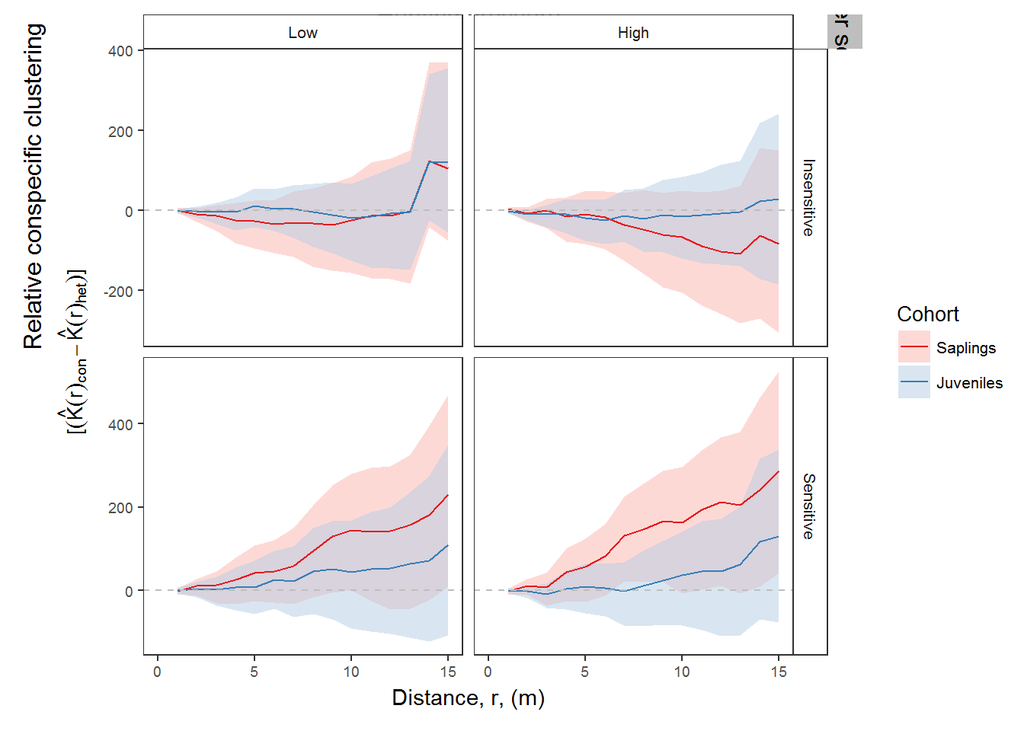

```r
################################################################################
## extract predictions and cis from model output
int.bi.plotdat <- kfunclme2plot(intMod.bi.boot, preddat=preddat.int)
int.uni.plotdat <- kfunclme2plot(intMod.uni.boot, preddat=preddat.int)

names(int.bi.plotdat)[2:4] <- paste(names(int.bi.plotdat)[2:4], 'bi', sep='.')
names(int.uni.plotdat)[2:4] <- paste(names(int.uni.plotdat)[2:4], 'uni', sep='.')
## Combine within and between cohort results
int.plotdat <- merge(int.uni.plotdat, int.bi.plotdat, by=c('distance', 'stage','huntpres', 'HSD'), all=T)

## More reader friendly labels
int.plotdat$stage <- factor(int.plotdat$stage, labels=c('Saplings', 'Juveniles'))
int.plotdat$huntpres <-  factor(int.plotdat$huntpres, labels=c('Low', 'High'))
int.plotdat$HSD <-  factor(int.plotdat$HSD, labels=c('Insensitive', 'Sensitive'))

## stat = identity hardwires the order - fixing so that isn't a problem
int.plotdat <- int.plotdat[order(int.plotdat$distance),]

## Make plots
pl.int.bi <-
    ggplot(int.plotdat, aes(x=distance, y=K.bi, ymin=lcl.bi, ymax=ucl.bi,
                    colour=stage, fill=stage)) +
    geom_ribbon(alpha=0.5, colour=NA) +  geom_line() +
    facet_grid(HSD~  huntpres, scales="free_y") +
    geom_abline(intercept=0, slope=0, linetype='dashed', col='grey') +
    theme_bw() + theme_cust + scale_x_continuous(limits=c(0, 15)) +
    scale_color_brewer(palette='Set1')+ scale_fill_brewer(palette='Pastel1') +
    labs(x='Distance, r, (m)',
         y=expression(paste('[', (hat(K)(r)[con]-hat(K)(r)[het]), ']')),
        color='Cohort', fill='Cohort')

pl.int.uni <- ggplot(int.plotdat, aes(x=distance, y=K.uni, ymin=lcl.uni, ymax=ucl.uni,
                                      colour=stage, fill=stage)) +
    geom_ribbon(alpha=0.5, colour=NA) +  geom_line() +
    facet_grid(HSD~  huntpres) +
    geom_abline(intercept=0, slope=0, linetype='dashed', col='grey') +
    theme_bw() + theme_cust + scale_x_continuous(limits=c(0, 15)) +
    scale_color_brewer(palette='Set1')+ scale_fill_brewer(palette='Pastel1') +
    labs(x='Distance, r, (m)',
         y=expression(paste('[', (hat(K)(r)[con]-hat(K)(r)[het]), ']')),
         color='Cohort', fill='Cohort')

## Format figures (1 and 3)
z.bi <- ggplot_gtable(ggplot_build(pl.int.bi))

##gtable_show_layout(z.bi)
## add a label at the top and side
z.bi <- gtable_add_rows(z.bi, height=unit(z.bi$heights[[3]], 'cm'), pos=2)
z.bi <- gtable_add_cols(z.bi, width=unit(z.bi$widths[[7]], 'cm'), pos=7)
z.bi <- gtable_add_cols(z.bi, width=z.bi$widths[[2]], pos=1)

z.bi <- gtable_add_grob(z.bi,
                     list(rectGrob(gp = gpar(fill=NA, col=NA, lwd=0)),
                          textGrob("Relative conspecific clustering", rot = 90,
                                   gp = gpar(fontsize=12))),
                     t=3, l=2, b=9, r=2, name = paste(runif(2)))

z.bi <- gtable_add_grob(z.bi,
                     list(rectGrob(gp=gpar(fill='grey', col=NA, lwd=0.2)),
                          textGrob("Hunting pressure",
                                   gp = gpar(fontsize=12))),
                     t=3, l=5, b=3, r=7, name = paste(runif(2)))
z.bi <- gtable_add_grob(z.bi,
                     list(rectGrob(gp = gpar(fill='grey', col=NA, lwd=0.2)),
                          textGrob("Disperser sensitivity", rot = -90,
                                   gp = gpar(fontsize=12))),
                     t=5, l=9, b=7, r=9, name = paste(runif(2)))
ggdraw(z.bi)
```

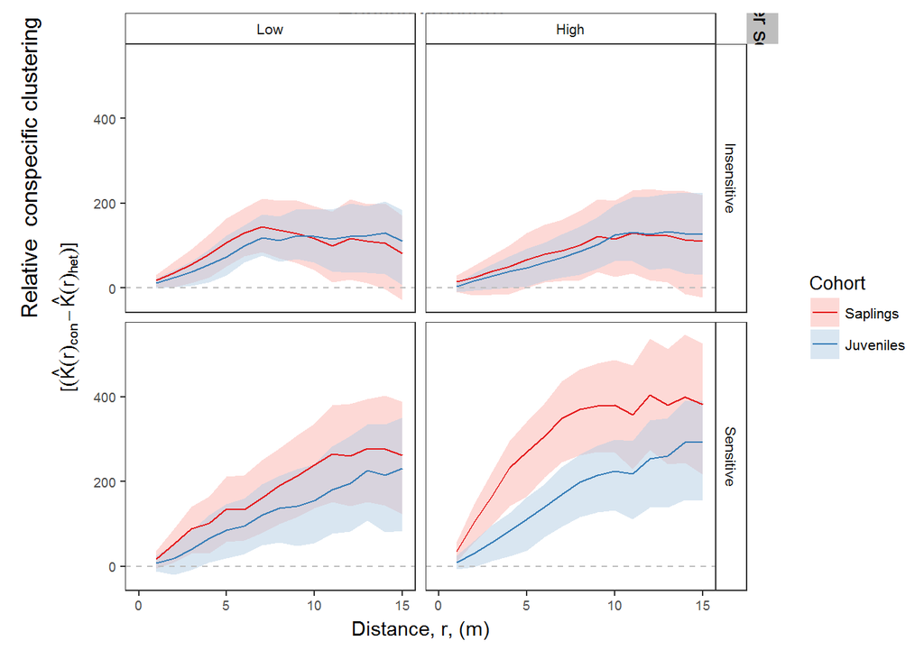

```r
## Univariate plot
z.uni <- ggplot_gtable(ggplot_build(pl.int.uni+theme_cust))
##gtable_show_layout(z.uni)
## add a label at the top and side
## extra row
z.uni <- gtable_add_rows(z.uni, height=unit(z.uni$heights[[3]], 'cm'),  pos=2)
## extra column
z.uni <- gtable_add_cols(z.uni, width=unit(z.uni$widths[[7]], 'cm'), pos=7)
z.uni <- gtable_add_cols(z.uni, width=z.uni$widths[[2]], pos=1)

z.uni <- gtable_add_grob(z.uni,
                     list(rectGrob(gp = gpar(fill=NA, col=NA, lwd=0)),
                          textGrob("Relative  conspecific clustering", rot = 90,
                                   gp = gpar(fontsize=12))),
                     t=3, l=2, b=9, r=2, name = paste(runif(2)))

## add hunting pressure label
z.uni <- gtable_add_grob(z.uni,
                         list(rectGrob(gp=gpar(fill='grey', col=NA, lwd=0.2)),
                              textGrob("Hunting pressure",
                                       gp = gpar(fontsize=12))),
                         t=3, l=5, b=3, r=7, name = paste(runif(2)))
## add disperser sensitivity label
z.uni <- gtable_add_grob(z.uni,
                         list(rectGrob(gp = gpar(fill='grey', col=NA, lwd=0.2)),
                              textGrob("Disperser sensitivity", rot = -90,
                                       gp = gpar(fontsize=12))),
                         t=5, l=9, b=7, r=9, name = paste(runif(2)))

ggdraw(z.uni)
```

```r
## Do not run this unless you want to change figures (and have done at least 999 iterations
## commented out to prevent mistakes

if(clusterNiter >= 999){
  png(file='../../huntingpaper/figures/Figure2_uni.png', width=6, height=4, units='in', res=600)
  ggdraw(z.uni)
  dev.off()

  pdf(file='../../huntingpaper/figures/Figure2_uni.pdf', width=6, height=4)
  ggdraw(z.uni)
  dev.off()

  png(file='../../huntingpaper/figures/Figure3_bi.png', width=6, height=4, units='in', res=600)
  ggdraw(z.bi)
  dev.off()

  pdf(file='../../huntingpaper/figures/Figure3_bi.pdf', width=6, height=4)
  ggdraw(z.bi)
  dev.off()

}
```

## 5 Ploting of individual species

We can plot the individual K-functions for each species x site combination. First we remove K functions based on < 15 individuals, which are meaningless on their own but can contribute with low weight to an overall analysis. We then need to select species that are represented in both cohorts at at least one hunted and one non-hunted site.

```r
hyperdat.uni.ind <- subset(hyperdat.uni.sel.c, N1 > 15)
hyperdat.uni.ind$Spp <- droplevels(hyperdat.uni.ind$Spp)
counts <- table(hyperdat.uni.ind$Spp, hyperdat.uni.ind$site)
counts <- as.matrix(counts)
## only include species that are represented in at least 1 hunted and one intact site (note
# that if a site has a species there will be 2 rows (saps + juvs)
counts <- counts[apply(counts, 1, function(x) any(x[c(1, 4, 5)] > 1) & any(x[c(2, 3, 6)] > 1)),]
sp.keep <- rownames(counts)
length(sp.keep) ## number of species that qualify
```

```
## [1] 26
```

```r
## Pulling out selected species
hyperdat.uni.ind <- subset(hyperdat.uni.sel, Spp %in% sp.keep)
hyperdat.bi.ind <- subset(hyperdat.bi.sel, Spp %in% sp.keep)
hyperdat.uni.ind <- hyperdat.uni.ind[order(hyperdat.uni.ind$N1),]
ntotals <- aggregate(N1 ~ Spp, data=subset(hyperdat.uni.sel.c, Spp %in% sp.keep), sum)
ntotals <- ntotals[rev(order(ntotals$N1)),]
disptype <- aggregate(HSD ~ Spp, data=hyperdat.uni.ind, mean)
## add dispersal data
disptype <- merge(disptype, ntotals)
```

Now we can select the most abundant species and plot them

```r
## order species by abundance
disptype <- disptype[order(disptype$N1, decreasing=T),]
head(disptype)
```

|  | Spp | HSD | N1 |
| --- | --- | --- | --- |
| 6 | Guarea kunthiana | 0.0 | 1961 |
| 16 | Pseudolmedia laevis | 0.7 | 1519 |
| 7 | Guarea macrophylla | 0.0 | 1382 |
| 18 | Quararibea wittii | 0.5 | 1164 |
| 13 | Otoba parvifolia | 0.0 | 1158 |
| 14 | Oxandra acuminata | 0.5 | 763 |

```r
## The subsetting in this function which will determine which species are included
## Including 1:4 so that 4 most abundant species are included
## If more are included we need to modify the plot code too

## Six most abundance species
sp2plot <- disptype$Spp[1:4]

ind.funcs <- hyperdat.uni.ind[hyperdat.uni.ind$Spp %in% sp2plot]
ind.funcs <- ind.funcs[order(ind.funcs$HSD)]
ind.funcs$Spp <- droplevels(ind.funcs$Spp)

sp.mods <- lapply(split(ind.funcs, f=ind.funcs$Spp), function(sp.dat){
  sp.mod <- lmHyperframe(sp.dat, 0:15, "stage*hunted", computeK=FALSE, minsamp=NA)
  preddat <- expand.grid(stage=levels(sp.dat$stage), hunted=levels(sp.dat$hunted))
  Xmat <- model.matrix(~stage*hunted, preddat)
  sp.boot  <- lm.t.boot(sp.mod,lincomb=Xmat, nsim=nsim, alpha=0.05, simple=FALSE)
  sp.dat <- with(sp.boot, {
    data.frame(
      Spp = unique(sp.dat$Spp),
      do.call('rbind', replicate(15, preddat, simplify=FALSE)),
      r=rep(1:15, each=nrow(preddat)),
      K=(do.call('c', lmKpred)),
      ucl=do.call('c', upper),
      lcl=do.call('c', lower)
       )})
})
sp.mods <- do.call('rbind', sp.mods)
sp.mods$hunted <- factor(sp.mods$hunted, levels=c('intact', 'hunted'),
                           labels=c('Low', 'High'))
sp.mods$stage <- factor(sp.mods$stage, levels=c('S', 'J'),
                           labels=c('Saplings', 'Juveniles'))

ind.funcs <- do.call('rbind', lapply(1:nrow(ind.funcs), function(i, dat){
  dat.i <- dat[i,]
  Ki <- data.frame(dat.i$K)[,c(1,3)]
  names(Ki) <- c('r', 'K')
  dat.i <- cbind(as.data.frame(dat.i[, c('stage', 'N1', 'N2', 'Spp', 'site',
                                         'pname', 'hunted', 'huntpres')]), Ki)
  return(dat.i)
}, dat=ind.funcs))
```

[output not shown]

[output cut: 79 more lines]

[output not shown]

```r
ind.funcs$stage <- factor(ind.funcs$stage, labels=c('Saplings', 'Juveniles'))
ind.funcs$Spp <-  factor(ind.funcs$Spp, levels=unique(ind.funcs$Spp))

ind.funcs$N <-  ntotals$N1[match(ind.funcs$Spp, ntotals$Spp)]
ind.funcs$HSD <- disptype$HSD[match(ind.funcs$Spp, disptype$Spp)]
ind.funcs$splab <- paste(ind.funcs$Spp, ' (n = ', ind.funcs$N, ')', sep='')
ind.funcs$hunted <- factor(ind.funcs$hunted, levels=c('intact', 'hunted'),
                           labels=c('Low', 'High'))

ind.funcs$site.lab <- ind.funcs$pname
ind.funcs$site.lab[ind.funcs$r != 13] <- NA
```

We can now prepare the plot and customise it to display all the information we need.

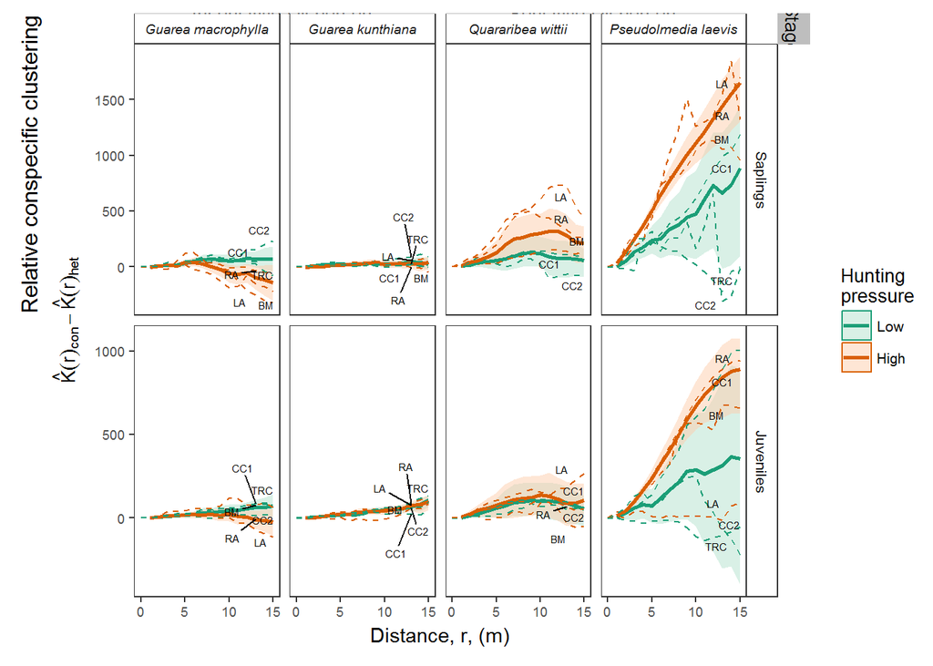

```r
sp.plot  <- ggplot(data=ind.funcs, aes(x=r, y=K)) +
  geom_ribbon(data=sp.mods, aes(ymin=lcl, ymax=ucl, colour=NULL, fill=hunted, group=hunted), alpha=0.5) +
  geom_line(data=sp.mods, aes(colour=hunted, group=hunted), size=1) +
  geom_line(aes(colour=hunted, group=stage:site), linetype='dashed') +
  geom_text_repel(aes(label=site.lab), size=2, show.legend=FALSE) + ##,) segment.color=0) +
  facet_grid(stage~ Spp, scales='free') +
    scale_colour_brewer(palette='Dark2') +
  scale_fill_brewer(palette='Pastel2') +
  ##geom_abline(intercept=0, lty='dashed', col='grey50') +
  theme_bw() + theme_cust +
  labs(x='Distance, r, (m)', y=expression(hat(K)(r)[con]-hat(K)(r)[het]),
       colour='Hunting\npressure', fill="Hunting\npressure")
sp.plot <- sp.plot + theme(strip.text.x=element_text(size=7, face='italic'))

z.sp <- ggplot_gtable(ggplot_build(sp.plot))
##gtable_show_layout(z.sp)
## add a label at the top and side

z.sp <- gtable_add_rows(z.sp, height=z.sp$heights[3], pos=2)
z.sp <- gtable_add_cols(z.sp, width=z.sp$widths[[11]], pos=11)
z.sp <- gtable_add_cols(z.sp, width=z.sp$widths[[2]], pos=1)
##sapply(z.test$grobs[grep('strip.absoluteGrob', sapply(z.test$grobs, function(x) x$name))], function(x) x$children[[1]]$gp$fill)

z.sp <- gtable_add_grob(z.sp,
                     list(rectGrob(gp = gpar(fill=NA, col=NA, lwd=0)),
                          textGrob("Relative conspecific clustering", rot = 90,
                                   gp = gpar(fontsize=12))),
                     t=4, l=2, b=8, r=2, name = paste(runif(2)))

z.sp <- gtable_add_grob(z.sp,
                     list(rectGrob(gp=gpar(fill='grey', col='grey', lwd=0.2)),
                          textGrob("Insensitive Dispersers",
                                   gp = gpar(fontsize=10))),
                     t=3, l=5, b=3, r=7, name = paste(runif(2)))
z.sp <- gtable_add_grob(z.sp,
                     list(rectGrob(gp=gpar(fill='grey', col='grey', lwd=0.2)),
                          textGrob("Sensitive Dispersers",
                                   gp = gpar(fontsize=10))),
                     t=3, l=9, b=3, r=11, name = paste(runif(2)))

z.sp <- gtable_add_grob(z.sp,
                     list(rectGrob(gp = gpar(fill='grey', col='grey', lwd=0.2)),
                          textGrob("Stage", rot = -90,
                                   gp = gpar(fontsize=10))),
                     t=5, l=13, b=7, r=13, name = paste(runif(2)))

ggdraw(z.sp)
```

```r
pdf('../../huntingpaper/figures/Figure1_bysp.pdf', width=8, height=4)
ggdraw(z.sp)
dev.off()
```

```r
png('../../huntingpaper/figures/Figure1_bysp.png', width=8, height=4, units='in', res=600)
ggdraw(z.sp)
dev.off()
```

We might also want to repeat for all species to make supplemental figure.

```r
ind.funcs.all <- hyperdat.uni.ind
ind.funcs.all <- ind.funcs.all[order(ind.funcs.all$HSD)]
ind.funcs.all$Spp <- droplevels(ind.funcs.all$Spp)

ind.funcs.all <- do.call('rbind', lapply(1:nrow(ind.funcs.all), function(i, dat){
  dat.i <- dat[i,]
  Ki <- data.frame(dat.i$K)[,c(1,3)]
  names(Ki) <- c('r', 'K')
  dat.i <- cbind(as.data.frame(dat.i[, c('stage', 'N1', 'N2', 'Spp', 'site',
                                         'pname', 'hunted', 'huntpres')]), Ki)
  return(dat.i)
}, dat=ind.funcs.all))
```

[output not shown]

[output cut: 676 more lines]

[output not shown]

```r
ind.funcs.all$stage <- factor(ind.funcs.all$stage, labels=c('Saplings', 'Juveniles'))
## order by disperser sensitivity
ind.funcs.all$Spp <-  droplevels(factor(ind.funcs.all$Spp, levels=disptype$Spp))

# ind.funcs.all$N <-  ntotals$N1[match(ind.funcs.all$Spp, ntotals$Spp)]
# ind.funcs.all$HSD <- disptype$HSD[match(ind.funcs.all$Spp, disptype$Spp)]
# ind.funcs.all$splab <- paste(ind.funcs.all$Spp, ' (n = ', ind.funcs.all$N, ')', sep='')
# ind.funcs.all$hunted <- factor(ind.funcs.all$hunted, levels=c('intact', 'hunted'),
#                            labels=c('Low', 'High'))

ind.funcs.all$site.lab <- ind.funcs.all$pname
ind.funcs.all$site.lab[ind.funcs.all$r != 13] <- NA

ind.funcs.all$N <-  ntotals$N1[match(ind.funcs.all$Spp, ntotals$Spp)]
ind.funcs.all$HSD <- disptype$HSD[match(ind.funcs.all$Spp, disptype$Spp)]
ind.funcs.all$splab <- paste(ind.funcs.all$Spp, '\n(n = ', ind.funcs.all$N, ')', sep='')
hsdbysp <- aggregate(HSD ~ splab, data=ind.funcs.all, unique)
hsdbysp <- hsdbysp[order(hsdbysp$HSD),]
ind.funcs.all$splab <- factor(ind.funcs.all$splab, levels=hsdbysp$splab)
ind.funcs.all$hunted <- factor(ind.funcs.all$hunted, levels=c('intact', 'hunted'),
                           labels=c('Low', 'High'))

plotgrps <- list(hsdbysp$splab[1:9], hsdbysp$splab[10:18], hsdbysp$splab[19:26])

sp.plot.all  <- lapply(plotgrps, function(grp)
  {
  ggplot(subset(ind.funcs.all, splab %in% grp), aes(x=r, y=K, colour=hunted, group=stage:site),
         fill='white')+
    geom_line() + geom_text_repel(aes(label=site.lab), size=2, show.legend=FALSE) +
    facet_grid( splab + HSD  ~stage, scales='free') +

    scale_colour_brewer(palette='Dark2') +
    geom_abline(intercept=0, lty='dashed', col='grey50') + theme_bw() + theme_cust +
    labs(x='Distance, r, (m)', y=expression(hat(K)(r)[con]-hat(K)(r)[het]),
         color='Hunting\npressure') +
    theme(strip.text.y=element_text(size=6, face='italic'))
})


z.sp.all <- lapply(sp.plot.all, function(pl) ggplot_gtable(ggplot_build(pl)))
##gtable_show_layout(z.sp.all[[1]])
## add a labels at the top and sides

z.sp.all <- lapply(z.sp.all, function(z)
{
  z <- gtable_add_rows(z, height=unit(z$heights[[3]], 'cm'), pos=2)
  z <- gtable_add_cols(z, width=unit(z$widths[[8]], 'cm'), pos=8)

  ## add header row with stage label
  z <- gtable_add_grob(z,list(rectGrob(gp=gpar(fill='grey', col='grey', lwd=0.2)),
                       textGrob("Stage",
                                gp = gpar(fontsize=10))),
                  t=3, l=4, b=3, r=6, name = paste(runif(2)))
  ## add column with disperser senstitivity label
  barlngth <-  length(z$heights) -3

  z <- gtable_add_grob(z,list(rectGrob(gp = gpar(fill='grey', col='grey', lwd=0.2)),
                                   textGrob("Disperser sensitivity", rot = -90,
                                            gp = gpar(fontsize=10))),
                              t=5, l=9, b=barlngth, r=9, name = paste(runif(2)))

  z <- gtable_add_cols(z, width=z$widths[[2]], pos=1)

  z <- gtable_add_grob(z, list(rectGrob(gp = gpar(fill=NA, col=NA, lwd=0)),
                                   textGrob("Relative Conpecific clustering", rot = 90,
                                            gp = gpar(fontsize=10))),
                              t=5, l=2, b=barlngth, r=2, name = paste(runif(2)))
  return(z)
  })

pdf('../../huntingpaper/figures/FigS2_byspecies_3pg.pdf', paper='A4', width=7, height=10)
lapply(z.sp.all, function(z) ggdraw(z))
```

```r
dev.off()
```

## 6 Description of data set

Extracing some summaries of the data to report in the paper

Some numbers on number of individuals/species etc etc

```r
##reliance on different dispersers
summary(hyperdat.uni.sel)
```

```
## hyperframe with 1042 rows and 27 columns
##         site         sp.id     stage    pppx  pppy    forest    pname
##     (factor)      (factor)     (factor) (ppp) (ppp) (factor)    (factor)
##  BM       :178   136    : 12   S:521                BM   :178   BM :178
##  CashuTr12:192   169    : 12   J:521                Cashu:416   CC1:224
##  CashuTr3 :224   208    : 12                        LA   :162   CC2:192
##  LA       :162   305    : 12                        RA   :158   LA :162
##  RA       :158   306    : 12                        TRC  :128   RA :158
##  TRC      :128   320    : 12                                    TRC:128
##                  (Other):970
##     hunted     lg.primates      lg.birds       huntpres            N1
##   (factor)       (numeric)     (numeric)      (numeric)      (integer)
##  intact:544   Min.   : 0.0   Min.   : 2.1   Min.   :-2.951   Min.   :  2
##  hunted:498   1st Qu.: 0.0   1st Qu.: 8.0   1st Qu.:-2.951   1st Qu.:  5
##               Median :15.9   Median :29.2   Median :-0.834   Median : 11
##               Mean   :17.5   Mean   :21.5   Mean   :-0.199   Mean   : 25
##               3rd Qu.:37.5   3rd Qu.:29.2   3rd Qu.: 2.737   3rd Qu.: 24
##               Max.   :37.5   Max.   :44.0   Max.   : 2.898   Max.   :700
##
##        N2                         Spp            LV              SV
##  (integer)                   (factor)      (numeric)       (numeric)
##  Min.   :1675   Capparis macrophylla: 12   Min.   :0.000   Min.   :0.000
##  1st Qu.:2448   Celtis schippii     : 12   1st Qu.:0.000   1st Qu.:0.000
##  Median :3536   Cordia nodosa       : 12   Median :0.500   Median :0.000
##  Mean   :3372   Guarea kunthiana    : 12   Mean   :0.427   Mean   :0.137
##  3rd Qu.:3933   Guarea macrophylla  : 12   3rd Qu.:0.800   3rd Qu.:0.200
##  Max.   :5414   Hasseltia floribunda: 12   Max.   :1.000   Max.   :1.000
##                 (Other)             :970
##        SB             Bat              TR             Wind
##  (numeric)       (numeric)       (numeric)       (numeric)
##  Min.   :0.000   Min.   :0.000   Min.   :0.000   Min.   :0.000
##  1st Qu.:0.000   1st Qu.:0.000   1st Qu.:0.000   1st Qu.:0.000
##  Median :0.000   Median :0.000   Median :0.000   Median :0.000
##  Mean   :0.282   Mean   :0.078   Mean   :0.025   Mean   :0.035
##  3rd Qu.:0.500   3rd Qu.:0.000   3rd Qu.:0.000   3rd Qu.:0.000
##  Max.   :1.000   Max.   :1.000   Max.   :1.000   Max.   :1.000
##
##       Expl           Unkwn         Abiotic           HSD            HID
##  (numeric)       (numeric)       (numeric)      (numeric)      (numeric)
##  Min.   :0.000   Min.   :0.00   Min.   :0.000   Min.   :0.00   Min.   :0.000
##  1st Qu.:0.000   1st Qu.:0.00   1st Qu.:0.000   1st Qu.:0.00   1st Qu.:0.200
##  Median :0.000   Median :0.00   Median :0.000   Median :0.50   Median :0.500
##  Mean   :0.008   Mean   :0.01   Mean   :0.042   Mean   :0.43   Mean   :0.561
##  3rd Qu.:0.000   3rd Qu.:0.00   3rd Qu.:0.000   3rd Qu.:0.80   3rd Qu.:1.000
##  Max.   :1.000   Max.   :1.00   Max.   :1.000   Max.   :1.00   Max.   :1.000
##
##  K     wts
##  (rat) (numeric)
##
##
##
##
##
##
##
```

```r
disp.list.uni <-  aggregate(cbind(LV, SV, SB, Bat, TR, Wind, Expl) ~Spp, subset(hyperdat.uni.sel.c,
                                                                stage=='S'), unique)
disp.list.bi <-  aggregate(cbind(LV, SV, SB, Bat, TR, Wind, Expl) ~Spp, subset(hyperdat.bi.sel.c,
                                                                stage=='S'), unique)
## Merge data from univariate and bivariate analyses
disp.list <- merge(disp.list.uni, disp.list.bi, by="Spp", all=T, suffix=c('uni', 'bi'))

## calculate number of species in each dispersal group
apply(disp.list[, -1], 2, function(x) sum(x>0, na.rm=T)) ## number dependent to some degree
```

```
##   LVuni   SVuni   SBuni  Batuni   TRuni Winduni Expluni    LVbi    SVbi    SBbi
##     131      79      89      22      12       0       0     110      66      66
##   Batbi    TRbi  Windbi  Explbi
##      19      11       0       0
```

```r
apply(disp.list[, -1], 2, function(x) sum(x==1, na.rm=T)) ## number totally dependent
```

```
##   LVuni   SVuni   SBuni  Batuni   TRuni Winduni Expluni    LVbi    SVbi    SBbi
##      32       2      34       8       1       0       0      29       2      28
##   Batbi    TRbi  Windbi  Explbi
##       7       1       0       0
```

```r
apply(disp.list[, -1], 2, function(x) sum(!is.na(x))) ## Total number of vertebrate dispersed species
```

```
##   LVuni   SVuni   SBuni  Batuni   TRuni Winduni Expluni    LVbi    SVbi    SBbi
##     198     198     198     198     198     198     198     164     164     164
##   Batbi    TRbi  Windbi  Explbi
##     164     164     164     164
```

```r
aggregate(Spp ~ pname, hyperdat.uni.wind, function(x) length(unique(x))) # species per site
```

| pname | Spp |
| --- | --- |
| BM | 7 |
| CC1 | 6 |
| CC2 | 4 |
| LA | 2 |
| RA | 2 |
| TRC | 1 |

```r
32/198; 29/164
```

```
## [1] 0.162
```

```
## [1] 0.177
```

```r
131/198; 110/164 ## proportion large vertebrate dispersed
```

```
## [1] 0.662
```

```
## [1] 0.671
```

```r
## Number of stems in each life stage.
aggregate(N1 ~ stage, hyperdat.uni.sel.c, sum) ##  univariate analysis
```

| stage | N1 |
| --- | --- |
| S | 8643 |
| J | 15865 |

```r
aggregate(N1 ~ stage, hyperdat.bi.sel.c, sum) ## bivariate analysis
```

| stage | N1 |
| --- | --- |
| S | 6788 |
| J | 12410 |

```r
aggregate(N2 ~ stage, hyperdat.bi.sel.c,  sum) ## number of adults in bivariate
```

| stage | N2 |
| --- | --- |
| S | 8133 |
| J | 8133 |

```r
aggregate(Spp ~ pname, hyperdat.uni.sel.c, function(x) length(unique(x))) # species per site
```

| pname | Spp |
| --- | --- |
| BM | 82 |
| CC1 | 104 |
| CC2 | 90 |
| LA | 79 |
| RA | 77 |
| TRC | 62 |

```r
aggregate(Spp ~ pname, hyperdat.bi.sel.c, function(x) length(unique(x))) # species per site
```

| pname | Spp |
| --- | --- |
| BM | 53 |
| CC1 | 67 |
| CC2 | 74 |
| LA | 60 |
| RA | 59 |
| TRC | 54 |

```r
## Numbers in the abiotically dispersed categories
aggregate(N1 ~ stage, hyperdat.uni.wind, sum) ##  univariate analysis
```

| stage | N1 |
| --- | --- |
| S | 634 |
| J | 792 |

```r
aggregate(N1 ~ stage, hyperdat.bi.wind, sum) ## bivariate analysis
```

| stage | N1 |
| --- | --- |
| S | 619 |
| J | 745 |

```r
aggregate(N2 ~ stage, hyperdat.bi.wind,  sum) ## number of adults in bivariate
```

| stage | N2 |
| --- | --- |
| S | 234 |
| J | 234 |

```r
aggregate(Spp ~ pname, hyperdat.uni.wind, function(x) length(unique(x))) # species per site
```

| pname | Spp |
| --- | --- |
| BM | 7 |
| CC1 | 6 |
| CC2 | 4 |
| LA | 2 |
| RA | 2 |
| TRC | 1 |

```r
aggregate(Spp ~ pname, hyperdat.bi.wind, function(x) length(unique(x))) # species per site
```

| pname | Spp |
| --- | --- |
| BM | 6 |
| CC1 | 5 |
| CC2 | 3 |
| LA | 3 |
| RA | 1 |
| TRC | 2 |